# Project 4, APS1070 Summer 2023

#### **Linear Regression - 16 points**

**Deadline: July 18th, 23:00**

**Academic Integrity**

This project is individual - it is to be completed on your own. If you have questions, please post your query in the APS1070 Piazza Q&A forums (the answer might be useful to others!).

Do not share your code with others, or post your work online. Do not submit code that you have not written yourself. Students suspected of plagiarism on a project, midterm or exam will be referred to the department for formal discipline for breaches of the Student Code of Conduct.

Please fill out the following:

- Your **name**: Rongxuan Du
- Your **student number**: 1004026528

### How to submit **(HTML [This notebook] + IPYNB + GitHub [Part 6])**

1. Download your notebook: `File -> Download .ipynb`
2. Click on the Files icon on the far left menu of Colab
3. Select & upload your `.ipynb` file you just downloaded, and then obtain its path (right click) (you might need to hit the Refresh button before your file shows up)
1. execute the following in a Colab cell:

   ```
   %%shell
   jupyter nbconvert --to html /PATH/TO/YOUR/NOTEBOOKFILE.ipynb
   ```

2. An HTML version of your notebook will appear in the files, so you can download it.
3. Submit **both** `HTML` and `IPYNB` files for this notebook on Quercus for grading.
4. Make sure you compeleted the last part on **GitHub** and added your link to the last cell here. The teaching team will view and grade your part 7 on GitHub.

Ref: https://stackoverflow.com/a/64487858

## Part 1 - Getting Started [2 marks]

```python
# %%shell
# jupyter nbconvert --to html /content/S23_APS1070_Project_4_Ron.ipynb
```

In this project, we are going to design a mathematical model that predicts electrical grid stability, as described in the paper below:

*Schäfer, Benjamin, et al. 'Taming instabilities in power grid networks by decentralized control.' The European Physical Journal Special Topics 225.3 (2016): 569-582.*

The following dataset contains 10000 instances, where each instance is a set of 12 features describing the grid's status. Our goal is to use these features to predict the `stab` column, which is a characteristic of the grid that represents its stability. We will make our predictions by implementing linear regression. Note that you can ignore the last column named `stabf` since this is a binary indicator showing whether the stability is above a certain threshold.

```python
import pandas as pd
import numpy as np

df=pd.read_csv("https://raw.githubusercontent.com/APS1070-W23/datasets/main/electrical_grid_stability_simulated_data.csv" , skipinitialspace=True)
```

Here are the steps to complete this portion:

1. Print the dataframe.
2. Prepare your dataset as follows: **[1.5]**
- Using `train_test_split` from Sklearn, split the dataset into training and validation sets ($80\%$ training, $20\%$ validation). When splitting, set `random_state=1`. **[0.5]**
- Standardize the data **manually** according to the same method as `StandardScaler` from sklearn, but you may not directly use `StandardScaler'. **[0.5]**
- Insert a first column of all $1$s in both the training and validation data sets.**[0.5]**
1. Explain why we should not insert the column of $1$s prior to standardization. **[0.5]**

   > It will be standardized to all zeros if it was inserted before the standardization and thus cannot be used in the following vectorized calculation.

```python
### YOUR CODE HERE ###
from sklearn.model_selection import train_test_split
print("Dataframe")
print(df)
X = df.loc[:,'tau1':'g4']
y = df.loc[:, 'stab']

# Train test split
X_train_original, X_valid_original, y_train_original, y_valid_original = train_test_split(X, y, test_size=0.2, random_state=1)

# Standardization
mean = X_train_original.mean()
std = X_train_original.std()
X_train_original -= mean
X_train_original /= std

# mean = X_valid_original.mean()
# std = X_valid_original.std()
X_valid_original -= mean
X_valid_original /= std

# Insert the first columns of 1s
all_1s = np.ones(X_train_original.shape[0])
X_train_original.insert(loc = 0, column = 'col1', value = all_1s)

all_1s = np.ones(X_valid_original.shape[0])
X_valid_original.insert(loc = 0, column = 'col1', value = all_1s)

print("Standardized X_train")
print(X_train_original)
```

```
Dataframe
          tau1      tau2      tau3      tau4        p1        p2        p3  \
0     2.959060  3.079885  8.381025  9.780754  3.763085 -0.782604 -1.257395
1     9.304097  4.902524  3.047541  1.369357  5.067812 -1.940058 -1.872742
2     8.971707  8.848428  3.046479  1.214518  3.405158 -1.207456 -1.277210
3     0.716415  7.669600  4.486641  2.340563  3.963791 -1.027473 -1.938944
4     3.134112  7.608772  4.943759  9.857573  3.525811 -1.125531 -1.845975
...        ...       ...       ...       ...       ...       ...       ...
9995  2.930406  9.487627  2.376523  6.187797  3.343416 -0.658054 -1.449106
9996  3.392299  1.274827  2.954947  6.894759  4.349512 -1.663661 -0.952437
9997  2.364034  2.842030  8.776391  1.008906  4.299976 -1.380719 -0.943884
9998  9.631511  3.994398  2.757071  7.821347  2.514755 -0.966330 -0.649915
9999  6.530527  6.781790  4.349695  8.673138  3.492807 -1.390285 -1.532193

            p4        g1        g2        g3        g4      stab     stabf
```

[output cut: 41 more lines]

## Part 2 - Linear Regression Using Direct Solution [1 marks]

Implement the direct solution of the linear regression problem on the training set. **[0.5]**

**Note: You should use scipy.linalg.inv to perform the inversion, as numpy.linalg.inv may caue an error.**

Report the root-mean-square error (RMSE) for both the training and validation sets. **[0.5]**

You may use `mean_squared_error` from Sklearn for computing the RMSE.

```python
### YOUR CODE HERE ###
import copy
from scipy.linalg import inv
from sklearn.metrics import mean_squared_error
import matplotlib.pyplot as plt

# Deepcopy
X_train = copy.deepcopy(X_train_original)
X_valid = copy.deepcopy(X_valid_original)
y_train = copy.deepcopy(y_train_original)
y_valid = copy.deepcopy(y_valid_original)

# analytical solution
W = np.dot(inv(np.dot(X_train.T, X_train)), np.dot(X_train.T, y_train))

# prediction
y_pred_train = np.dot(X_train, W)
y_pred_valid = np.dot(X_valid, W)

rmse_train = mean_squared_error(y_train, y_pred_train, squared=False)
rmse_valid = mean_squared_error(y_valid, y_pred_valid, squared=False)
print('RMSE for training set = {}'.format(rmse_train))
print('RMSE for valid set = {}'.format(rmse_valid))
```

```
RMSE for training set = 0.021942394612619577
RMSE for valid set = 0.021928218804309854
```

## Part 3 - Full Batch Gradient Descent [3 marks]

We will now implement a "full batch" gradient descent algorithm and record the training time for our model. Recall that the full batch gradient descent is, $$w_t = w_{t-1} - \alpha~g_t$$ where $\alpha$ is the learning rate and $g_t$ is your gradient, computed on the entire data.

Here are the steps for this part:

- Implement gradient descent for linear regression using a fixed learning rate of $\alpha= 0.01$, and iterate until your model's **validation** RMSE converges.

  We consider the gradient descent as having converged when RMSE on the validation set using gradient descent satisfies:

  $$ RMSE_\text{GD} \leq 1.001 \times RMSE_\text{Direct Solution}$$

  where $RMSE_\text{Direct Solution}$ is the RMSE on the validation set using the direct solution that you calculated in the previous part.

  We refer to the quantity $RMSE_\text{Direct Solution}\times 1.001$ as the convergence threshold (CT).
- Record the training time (from the first iteration until convergence) using the `time.time()` function. Be sure to compute the gradients yourself! Take a look at the code provided in the tutorial. **[1]**
- Plot the training RMSE and the validation RMSE vs. epoch on the same figure. **[1]**
- Comment on overfitting/underfitting by observing the training and validation RMSE **[1]**

> The plot showed the model did not show overfitting on the dataset. It showed underfitting at the begining of the calculation as the epoches number was not enough to get the accurate model output.

**Hint**: Initialize your weights with small random numbers (<$0.001$)

```python
ct = rmse_valid * 1.001
ct
```

```
0.021950147023114163
```

```
--- Total Training Time: 0.6654505729675293 (s) ---
```

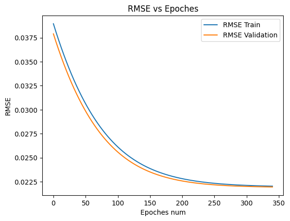

```python
import time

start_time = time.time() ## Records current time

## GD Script -- Sample code in tutorial! ##
# Convergence threshold
ct = rmse_valid * 1.001
# Params init
np.random.seed(0)
w = (np.random.random(X_train.shape[1]) / 1000)
rmse_train_arr = []
rmse_valid_arr = []

rmse = np.inf
lr = 0.01
epoch = 0

# Full batch GD
while rmse > ct:
  y_pred_train = np.dot(X_train, w.T)
  rmse = mean_squared_error(y_pred_train, y_train, squared=False)
  rmse_train_arr.append(rmse)

  y_pred_valid = np.dot(X_valid, w)
  rmse = mean_squared_error(y_pred_valid, y_valid, squared=False)
  rmse_valid_arr.append(rmse)

  gradient = (1 / y.shape[0] * np.dot(X_train.T, (y_pred_train - y_train)))
  w = w - lr * gradient
  epoch += 1

print("--- Total Training Time: %s (s) ---" % (time.time() - start_time))

# Plot
plt.plot(np.arange(epoch), rmse_train_arr, label='RMSE Train')
plt.plot(np.arange(epoch), rmse_valid_arr, label='RMSE Validation')
plt.title('RMSE vs Epoches')
plt.xlabel('Epoches num')
plt.ylabel('RMSE')
plt.legend()
```

```python
# while rmse > ct:
#   y_pred_train = np.dot(X_train, w)
#   rmse = mean_squared_error(y_pred_train, np.array(y_train).reshape(-1, 1), squared=False)
#   rmse_train_arr.append(rmse)

#   y_pred_valid = np.dot(X_valid, w)
#   rmse = mean_squared_error(y_pred_valid, np.array(y_valid).reshape(-1, 1), squared=False)
#   rmse_valid_arr.append(rmse)

#   gradient = (1 / y.shape[0] * np.dot((y_pred_train - np.array(y_train).reshape(-1, 1)).T, X_train))[0]
#   w = w - lr * gradient.reshape(-1, 1)
#   epoch += 1
# print(rmse_train_arr)
# print("--- Total Training Time: %s (s) ---" % (time.time() - start_time))
# # Plot
# plt.plot(np.arange(epoch), rmse_train_arr, label='RMSE Train')
# plt.plot(np.arange(epoch), rmse_valid_arr, label='RMSE Validation')
# plt.legend()
```

## Part 4 - Mini-batch and Stochastic Gradient Descent [4 marks]

Write a function that performs mini-batch gradient descent until the convergence threshold (CT) is reached. **[1]**

The inputs of that function are:

- Input data (training/validation), Batch size, Learning Rate, Convergence Threshold (CT)

Your function will return the following arrays:

- The final weights after training.
- The training RMSE at each epoch.
- The validation RMSE at each epoch.
- An array that has the elapsed time from the start of the training process to the end of each epoch (e.g., if each epoch takes exactly 2 seconds, the array would look like: [2 4 6 8 ...]).

Notes:

- For certain batch sizes, GD might not converge to a solution. For that reason, you need to check the RMSE of the validation/training set at each epoch, and if it's getting larger and larger, you should stop the training for that case (the design is up to you!).
- CT will help you to know when your model is converged.
- **Important: after each epoch, you need to shuffle the entire training set.** This ensures that new mini-batches are selected for every epoch. Hint: use `np.random.permutation`.

Let's now use the function to investigate the effect of batch size on convergence. When the batch size is 1, we call that stochastic gradient descent. When the batch size equals the # of training data, it is full-batch (i.e., all data points are used at every iteration). Anywhere in between is mini-batch (we use some of the data).

- Sweep different values for the mini-batch size (at least 5 values that **converge**), each time using a learning rate of $\alpha= 0.01$. **Hint: Try batch sizes that are powers of two (e.g., 2,4,8,16,32,64,128...).** These batch sizes fit better on the hardware and may achieve higher performance. **[0.5]**

Provide the following $3$ plots:

1. Plot training and validation RMSE vs. **epoch** for all the **converging** batch sizes (some batch sizes might not converge) in a figure. The X-axis is Epoch # and the Y-axis is RMSE. **[0.5]**
2. Plot training and validation RMSE vs. **time** for all the **converging** batch sizes in a figure. The X-axis is Time, and the Y-axis is RMSE. **[0.5]**
3. Plot Total training time (y-axis) vs. Batch size (x-axis). **[0.5]**

Describe your findings, including the main takeaways from each of your plots. **[1]**

> The plot showed the RMSE decreased as the number of epoches increase. However, large batch size (>128) costs more time and epoches to achieve the desired RMSE.

> The smaller batch size ([32, 128])the gradient descent used the shorter training time and smaller epoches number the model cost.

> However, too small batch size (< 32) might lead to divergence and flucuate at some number which is higher than the desired RMSE (was not shown in the graph but occured in the experienment). A trade-off need to be made when choosing the size of batches in gradient desecent model training.

```python
### YOUR CODE HERE ###
def create_batches(X, y, size):
  mini_batches = []
  X_y = np.hstack((X, y))

  i = 0
  while i < X_y.shape[0] - size:
    X_mini = X_y[i : i + size, :-1]
    y_mini = X_y[i : i + size, -1].reshape(-1, 1)
    mini_batches.append((X_mini, y_mini))
    i += size

  if i < X_y.shape[0]:
    mini_batches.append( (X_y[i : X_y.shape[0], :-1], X_y[i : X_y.shape[0], -1].reshape(-1, 1)) )

  return mini_batches

def gradient_descent(X_train, y_train, X_valid, y_valid, batch_size: int, lr: float, ct: float):
  # Init params
  np.random.seed(0)
  w = np.random.random(X_train.shape[1]) / 1000
  rmse_train_arr = []
  rmse_valid_arr = []
  epoches_time = []
  rmse = np.inf
  rmse_previous = np.inf
  epoch = 0
  conv_flag = 1

  # Record epoch time
  start_time = time.time()

  while rmse > ct:

    # Shuffle the data
    permutation = list(np.random.permutation(X_train.shape[0]))
    X_train = X_train.iloc[permutation, :]
    y_train = y_train.iloc[permutation, :]

    # Create mini-batches
    batches_train = create_batches(X_train, y_train, batch_size)
    batches_valid = create_batches(X_valid, y_valid, batch_size)

    # Update gradient and w based on mini-batches
    for batch in batches_train:
      X_mini, y_mini = batch
      y_pred_mini = np.dot(X_mini, w.T)
      gradient = (1 / y_mini.shape[0] * np.dot(X_mini.T, (y_pred_mini.reshape(-1,1) - y_mini)))
      w = w - lr * gradient.reshape(1, -1)

    epoches_time.append(time.time() - start_time)

    # Calculate RMSE
    y_pred_train = np.dot(X_train, w.T)
    rmse = mean_squared_error(y_pred_train, y_train, squared=False)
    rmse_train_arr.append(rmse)

    y_pred_valid = np.dot(X_valid, w.T)
    rmse = mean_squared_error(y_pred_valid, y_valid, squared=False)
    rmse_valid_arr.append(rmse)

    # Check if diverge
    if rmse < rmse_previous:
      rmse_previous = rmse
    else:
      conv_flag = 0
      break

    epoch += 1

  return w, rmse_train_arr, rmse_valid_arr, epoches_time, epoch, conv_flag
```

```python
# Set Params
batch_size = [2**i for i in range(1, 10)]
lr = 0.01
final_weights = []
rmse_train_plot = []
rmse_valid_plot = []
epoches_time_plot = []
epoches_num = []
conv_flags = []
conv_batch_size = []

# Call GD
for size in batch_size:
  final_w, rmse_train_arr, rmse_valid_arr, epoches_time, epoches, conv_flag = gradient_descent(
      X_train, y_train.to_frame(), X_valid, y_valid.to_frame(), batch_size=size, lr=lr, ct=ct)
  conv_flags.append(conv_flag)
  if conv_flag:
    conv_batch_size .append(size)
    final_weights.append(final_w)
    rmse_train_plot.append(rmse_train_arr)
    rmse_valid_plot.append(rmse_valid_arr)
    epoches_time_plot.append(epoches_time)
    epoches_num.append(epoches)


  print('------Batch size = %d; CT = %f; lr = 0.01 were used---------------------' % (size, ct))
  if conv_flag:
    print("The batch size lead to a convergence")
  else:
    print("The batch size did not lead to a convergence")
  print('final weight is %s' % final_w)
  print('RMSE for training set is %s' % rmse_train_arr)
  print('RMSE for validation setis %s' % rmse_valid_arr)
  print('Epoches time used is %s' % epoches_time)
  print()
```

```
------Batch size = 2; CT = 0.021950; lr = 0.01 were used---------------------
The batch size did not lead to a convergence
final weight is [[ 0.015012    0.00933859  0.00900348  0.00998544  0.01256969  0.00116185
   0.00158579  0.00053813 -0.00072661  0.01085715  0.00997807  0.01191649
   0.00968626]]
RMSE for training set is [0.022137253467323433, 0.022204781629059655]
RMSE for validation setis [0.022169468920958786, 0.022188641246238466]
Epoches time used is [0.16058921813964844, 0.25847649574279785]

------Batch size = 4; CT = 0.021950; lr = 0.01 were used---------------------
The batch size did not lead to a convergence
final weight is [[ 0.01533653  0.00967205  0.00981673  0.01009925  0.01127833  0.00100065
   0.00161799  0.00068388 -0.00062301  0.01105484  0.01007121  0.01198618
   0.01036853]]
RMSE for training set is [0.02203367493523801, 0.022042499546440802]
RMSE for validation setis [0.02204449654621164, 0.02206086834977364]
Epoches time used is [0.04944157600402832, 0.10404753684997559]

------Batch size = 8; CT = 0.021950; lr = 0.01 were used---------------------
The batch size did not lead to a convergence
final weight is [[ 0.01565071  0.00978572  0.01030578  0.01010237  0.01083657  0.00097165
   0.0014641   0.00072603 -0.00046126  0.01094586  0.0100218   0.01177168
   0.01086979]]
RMSE for training set is [0.02199323440180826, 0.02199862807531637]
RMSE for validation setis [0.021997758941298486, 0.02202878689905365]
Epoches time used is [0.04385972023010254, 0.07712244987487793]

------Batch size = 16; CT = 0.021950; lr = 0.01 were used---------------------
The batch size did not lead to a convergence
final weight is [[ 0.01576447  0.00982103  0.0104153   0.0101139   0.01064097  0.00104711
   0.00117276  0.00073684 -0.00031366  0.01079792  0.01020206  0.01150331
   0.01101876]]
RMSE for training set is [0.021964940910719943, 0.021971297708521742]
RMSE for validation setis [0.021954677568585785, 0.021993066160316547]
Epoches time used is [0.028374195098876953, 0.04985690116882324]

------Batch size = 32; CT = 0.021950; lr = 0.01 were used---------------------
The batch size lead to a convergence
final weight is [[ 1.57292762e-02  9.89666102e-03  1.02627112e-02  1.01953160e-02
   1.01731434e-02  1.19587831e-03  5.97356910e-04  7.39149951e-04
```

[output cut: 27 more lines]

```
final weight is [[0.01490157 0.00926659 0.00979681 0.00982225 0.00981092 0.00100083
  0.0007727  0.00075535 0.00014694 0.00999403 0.01019184 0.0106324
  0.00999798]]
RMSE for training set is [0.031897074789766035, 0.027555054379970502, 0.025025458030859683, 0.023588212848790303, 0.02281340377365806, 0.022398842746280328, 0.022178744663604172, 0.022064988785520104, 0.022006998463337826]
RMSE for validation setis [0.031073716219464077, 0.026933814131524222, 0.02456667170025607, 0.023258275495205333, 0.022574298515679568, 0.0222275631466693, 0.022053737601017614, 0.021973335425830055, 0.0219384786019894]
Epoches time used is [0.010300159454345703, 0.031957387924194336, 0.04577279090881348, 0.057602643966674805, 0.0687415599822998, 0.07978439331054688, 0.09130740165710449, 0.10247945785522461, 0.1137392520904541]

------Batch size = 512; CT = 0.021950; lr = 0.01 were used---------------------
The batch size lead to a convergence
final weight is [[0.01478031 0.00923488 0.00980429 0.00962683 0.00968467 0.00099275
  0.00075354 0.0007378  0.00019765 0.00986732 0.01010229 0.01053987
  0.00993094]]
RMSE for training set is [0.03502838427706326, 0.03191374504392024, 0.029459176020152262, 0.027559238486310093, 0.02610779267773902, 0.025011569627516942, 0.024191876834897506, 0.023587744119100716, 0.02313938758525246, 0.022811278988241826, 0.022572964638396392, 0.022397918730807237, 0.022270925709…
RMSE for validation setis [0.03409420275175939, 0.031092183617897468, 0.028741940026659207, 0.026937861005504056, 0.025572765884379383, 0.024553825631737587, 0.02380229518087446, 0.023256551104572643, 0.02285866862432632, 0.02257311103042629, 0.02237055389786156, 0.02222598322013358, 0.0221239587667…
Epoches time used is [0.0073320865631103516, 0.019003629684448242, 0.029696941375732422, 0.04093670845031738, 0.05231881141662598, 0.06302857398986816, 0.07364344596862793, 0.08431529998779297, 0.09509396553039551, 0.10583305358886719, 0.11624836921691895, 0.12665271759033203, 0.13691067695617676, 0…
```

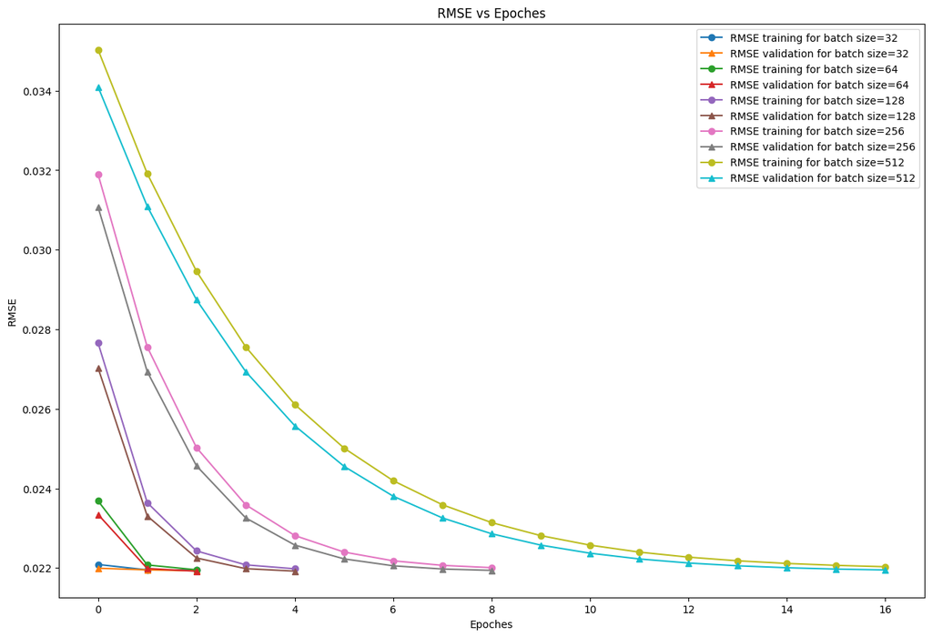

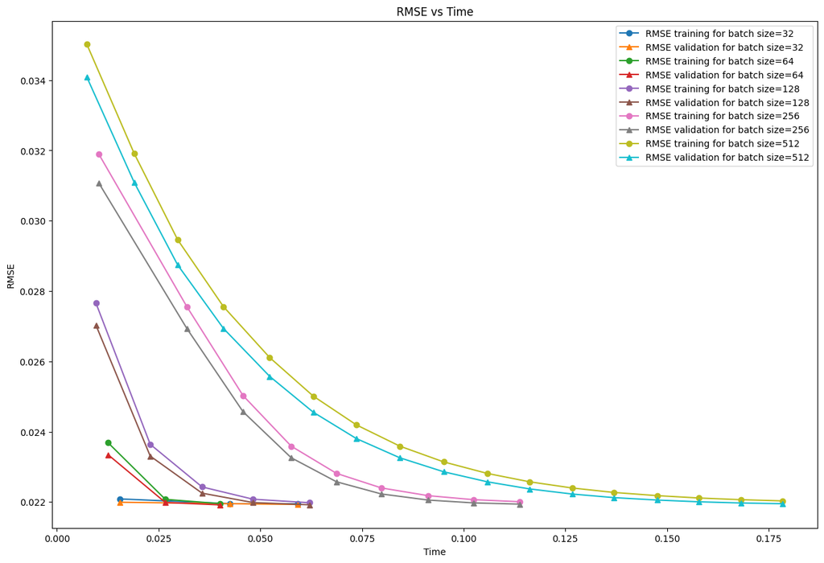

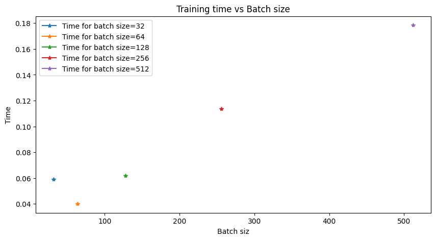

```python
# Plot
# RMSE vs epoches
plt.figure(figsize=(15,10))
for i in range(len(rmse_train_plot)):
  plt.plot(np.arange(epoches_num[i]), rmse_train_plot[i], 'o-', label='RMSE training for batch size=%s' % conv_batch_size[i])
  plt.plot(np.arange(epoches_num[i]), rmse_valid_plot[i], '^-', label='RMSE validation for batch size=%s' % conv_batch_size[i])

plt.legend()
plt.title('RMSE vs Epoches')
plt.xlabel('Epoches')
plt.ylabel('RMSE')

# RMSE vs time
plt.figure(figsize=(15,10))
for i in range(len(rmse_train_plot)):
  plt.plot(epoches_time_plot[i], rmse_train_plot[i], 'o-', label='RMSE training for batch size=%s' % conv_batch_size[i])
  plt.plot(epoches_time_plot[i], rmse_valid_plot[i], '^-', label='RMSE validation for batch size=%s' % conv_batch_size[i])

plt.legend()
plt.title('RMSE vs Time')
plt.xlabel('Time')
plt.ylabel('RMSE')

# Training time vs Batch size
plt.figure(figsize=(10,5))
for i in range(len(rmse_train_plot)):
  plt.plot(conv_batch_size[i], epoches_time_plot[i][-1], '*-', label='Time for batch size=%s' % conv_batch_size[i])

plt.legend()
plt.title('Training time vs Batch size')
plt.xlabel('Batch siz')
plt.ylabel('Time')
```

## Part 5 - Gradient Descent Learning Rate [3 marks]

Use the function that you designed in Part 4 to investigate the effect of learning rate on convergence.

1. Pick 3 batch sizes that do not converge with a learning rate of $\alpha= 0.01$ (last part) and try to find a learning rate that results in convergence for each batch size. Report your findings in a table. Mention batch size, learning rate, and training and validation RMSE. **[1]**
2. Select the best batch size based on Part 4's fastest convergence time and sweep the learning rate (at least 10 values, all should converge) while applying Mini-batch GD.
   - Plot the training and validation RMSE vs. **epoch** (x-axis) for all the learning rates that you tried in a figure. **[0.5]**
   - Plot the training and validation RMSE vs. **time** (x-axis) for all the learning rates that you tried in a figure. **[0.5]**
   - Describe your findings, including the main takeaways from each of your plots. **[1]**

```python
### YOUR CODE HERE ###

# batch size = 4, 8, 16 were picked
# Set Params
batch_size = [2**i for i in range(2, 5)]
lrs = [0.01, 0.008, 0.006, 0.004, 0.002]
rmse_train_plot = []
rmse_valid_plot = []
conv_batch_size = []
conv_lr = []

# Call GD
for size in batch_size:
  for lr in lrs:
    final_w, rmse_train_arr, rmse_valid_arr, epoches_time, epoches, conv_flag = gradient_descent(
        X_train, y_train.to_frame(), X_valid, y_valid.to_frame(), batch_size=size, lr=lr, ct=ct)
    # print(conv_flag)
    if conv_flag:
      rmse_train_plot.append(rmse_train_arr)
      rmse_valid_plot.append(rmse_valid_arr)
      conv_batch_size.append(size)
      conv_lr.append(lr)
      break


# Tabular visulization
print('Batch size = 4, 8, 16 were picked. Divergence cases when LR = 0.01:')
pd.DataFrame([conv_batch_size, conv_lr, rmse_train_plot, rmse_valid_plot],
             index=['Batch Size', 'New LR Made It Converged', 'RMSE for Training', 'RMSE for Validation'],
             columns=['First Case', 'Second Case', 'Third Case'])
```

```
Batch size = 4, 8, 16 were picked. Divergence cases when LR = 0.01:
```

|  | First Case | Second Case | Third Case |
| --- | --- | --- | --- |
| Batch Size | 4 | 8 | 16 |
| New LR Made It Converged | 0.002 | 0.004 | 0.008 |
| RMSE for Training | [0.0219641013281412] | [0.021964055150959606] | [0.02196392500983642] |
| RMSE for Validation | [0.02193998998543929] | [0.021940028725192618] | [0.02194012755172625] |

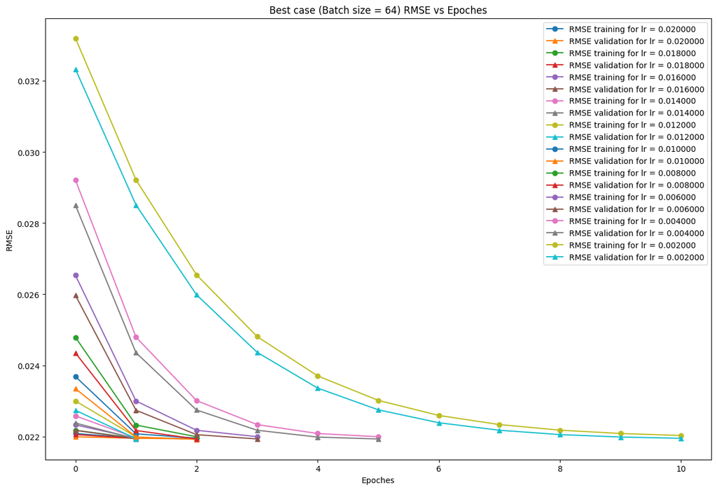

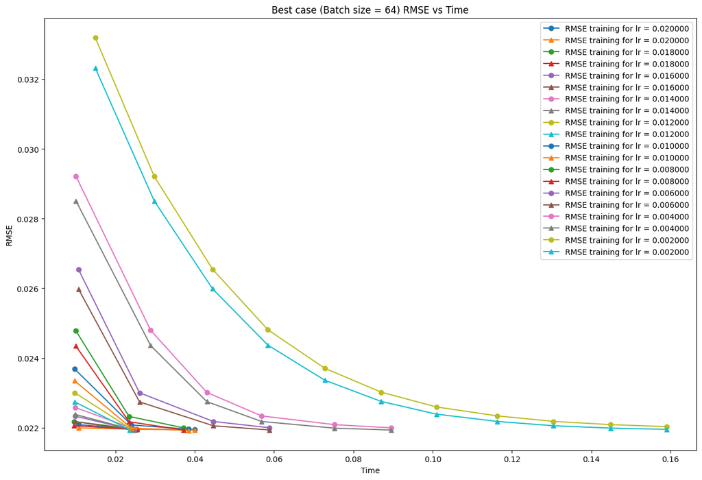

```python
# Batch size = 64 was selected
# Set Params
batch_size = 64
lrs = [(0.02 - i * 0.002) for i in range(10)]
# print(lrs)
rmse_train_plot = []
rmse_valid_plot = []
epoches_time_plot = []
epoches_num = []
conv_lr = []

# Call GD
for lr in lrs:
  final_w, rmse_train_arr, rmse_valid_arr, epoches_time, epoches, conv_flag = gradient_descent(
      X_train, y_train.to_frame(), X_valid, y_valid.to_frame(), batch_size=batch_size, lr=lr, ct=ct)
  # print(conv_flag)
  if conv_flag:
    rmse_train_plot.append(rmse_train_arr)
    rmse_valid_plot.append(rmse_valid_arr)
    epoches_time_plot.append(epoches_time)
    epoches_num.append(epoches)
    conv_lr.append(lr)

# Plot
# RMSE vs epoches
plt.figure(figsize=(15,10))
for i in range(len(lrs)):
  plt.plot(np.arange(epoches_num[i]), rmse_train_plot[i], 'o-', label='RMSE training for lr = %f' % lrs[i])
  plt.plot(np.arange(epoches_num[i]), rmse_valid_plot[i], '^-', label='RMSE validation for lr = %f' % lrs[i])

plt.legend()
plt.xlabel('Epoches')
plt.ylabel('RMSE')
plt.title('Best case (Batch size = 64) RMSE vs Epoches')

# RMSE vs time
plt.figure(figsize=(15,10))
for i in range(len(rmse_train_plot)):
  plt.plot(epoches_time_plot[i], rmse_train_plot[i], 'o-',  label='RMSE training for lr = %f' % lrs[i])
  plt.plot(epoches_time_plot[i], rmse_valid_plot[i], '^-',  label='RMSE training for lr = %f' % lrs[i])

plt.legend()
plt.xlabel('Time')
plt.ylabel('RMSE')
plt.title('Best case (Batch size = 64) RMSE vs Time')
```

## Part 6 - Getting started with Github [3 marks]

This final part of the project assignment is to be completed independently from Parts 1 - 5. In this part you will be completing some additional coding tasks using a different dataset and submitting your results on Github. To access this part of the assignment and upload your answers, you will need to use Github. Please complete the following step-by-step instructions:

1. Create a Github account and install git for Windows or Mac:
   - https://git-scm.com/download/win
   - https://git-scm.com/download/mac
2. Open this link: https://classroom.github.com/a/owI3c1qy to create your assignment repository in GitHub. You should get a link similar to:

   ```
   https://github.com/APS1070-S23-Project-4/project-4-*********
   https://github.com/APS1070-S23/project-4-Ron0817
   ```

   This your private repository to get this part questions and upload your answers. **Copy this link to the text box below to be graded for this part.**
1. Open `Git Bash`, the app you downloaded in step `0`, and set your Email and username by:

   ```
   git config --global user.email “<your-GitHub-email>”
   git config --global user.name “<your-GitHub-username>”
   ```

2. Create a folder for the course on your computer and `cd` to that. `cd` means `Change Directory`. For example, on a Windows machine, where I have a folder on "C:\aps1070":

   ```
   cd c:aps1070
   ```

3. Get your assignment by the link you got in step 1:

   ```
   git clone https://github.com/APS1070-S23-Project-4/project-4-*********
   ```

4. A new folder should be created in your directory similar to:

   ```
   C:\aps1070\project-4-********
   ```

   This folder has an `ipynb` notebook which you need to manually upload to colab and answer its questions.
5. After you finished working on this notebook, download the notebook from colab and move it to the directory in step 5.
6. Replace the old notebook with the new one that has your answers. Make sure your completed notebook has the same name as the original notebook you downloaded.
7. To submit your work, follow:

   ```
   cd <your assignment folder>
   git add S23_Project_4_git.ipynb
   git commit -m “Final Submission”
   git push
   ```

   If you had any problem with pushing your work on GitHub you can try one of following commands:

   ```
   git push --force
   or
   git push origin HEAD:main
   ```

8. Make sure your submission is ready for grading. Open the private repository link in your browser and make sure you can see your final submission with your latest changes there. **Only you and the teaching team can open that link.**

MY LINK: https://github.com/APS1070-S23/project-4-Ron0817